# Forecasting

David Asare Kumi

7/18/2019

## Forecasting

Forecasting simply applies to time series data.

### What is different

- Data are dependent over time (this makes prediction challenging).
- Specific pattern types.
1. Trends; long term increase or decrease.
2. Seasonal patterns; patterns related to time of week,month,year etc.
3. Cycles; patterns that rise and fall periodically.
- Subsampling into training/test is more complicated.
- Similar issues arise in spatial data.
1. Dependency between nearby observations.
2. Location specific effects.
- Typically, goal is to predict one or more observations into the future.
- All standard predictions can be used (with caution!)
- Beware of spurious correlations. A spurious correlation is a relationship between two variables that appear to have interdependence or association with each other but actually do not. Spurious correlation is often caused by a third factor that is not apparent at the time of examination. The third factor can be said to be a confounding factor.
- Beware of extrapolation; This type of extrapolation can be dangerous in the future.

## Example: Time series decomposition

- Trend; Consistently increasing pattern over time.
- Seasonal; When there is a pattern over a fixed period of time that recurs.
- Cyclic; When data rises and falls over non fixed periods.

## Decompose a time series into parts.

- plot(decompose(ts1),xlab="Years + 1)

## Training and test sets

- ts1Train = window(ts1,start=1,end=5).
- ts1Test = window(ts1,start=5,end=(7-0.01)).
- ts1Train (this gives the table).
- We use consecutive time points for our train/test set.

## Different ways of forecasting (install and load forecast)

1. Simple moving average (sma)/ma. plot(ts1Train). lines(ma(ts1Train,order=3),col=“red”)
2. Exponential Smoothing; Example- simple exponential smoothing. ets1 = ets(ts1Train,model=“MMM”).
3. fcast = forecast(ets1).
4. plot(fcast)
5. lines(ts1Test,col=“red”)

## Get the accuracy

- accuracy(fcast,ts1Test)

## install package forecast

- load forecast library; library(forecast).
- find the number of rows(years); rows= ceiling(length(ts)/12).
- use 90% of the data to create training set; tsTrain = window(ts,start=1,end=floor(rows*0.9)-0.01).
- use the rest of the data to create test set; tsTest = window(ts,start=floor(row*0.9)).
- plot the training set; plot(tsTrain).
- add the moving average in red; lines(ma(tsTrain,order=3),col=“red”).
- note that ts is time series.

## Notes and further Resources

- Forecasting and time series prediction is an entire field.
- Rob Hyndman’s Forecasting; principles and practice is a good place to start.
- Cautions
1. Be wary of spurious correlations.
2. Be careful how far you predict (extrapolation).
3. Be wary of dependencies over time.
4. See quantmod or quandl packages for financial related problems.

## Unsupervised Prediction

### Key Ideas

- Sometimes you don’t know the labels for prediction.
- To build a predictor;
1. Create clusters.
2. Name clusters(challenging).
3. Build predictor for clusters.
- In a new data set;
1. Predict clusters.

## Iris Example; ignoring species labels

```r
library(ggplot2)
library(lattice)
library(gridExtra)
library(caret)
library(rpart)
data(iris)
inTrain <-createDataPartition(y=iris$Species,p=0.7,list=FALSE)
training <-iris[inTrain,]
testing <-iris[-inTrain,]
dim(training)
```

```
## [1] 105   5
```

```r
dim(testing)
```

```
## [1] 45  5
```

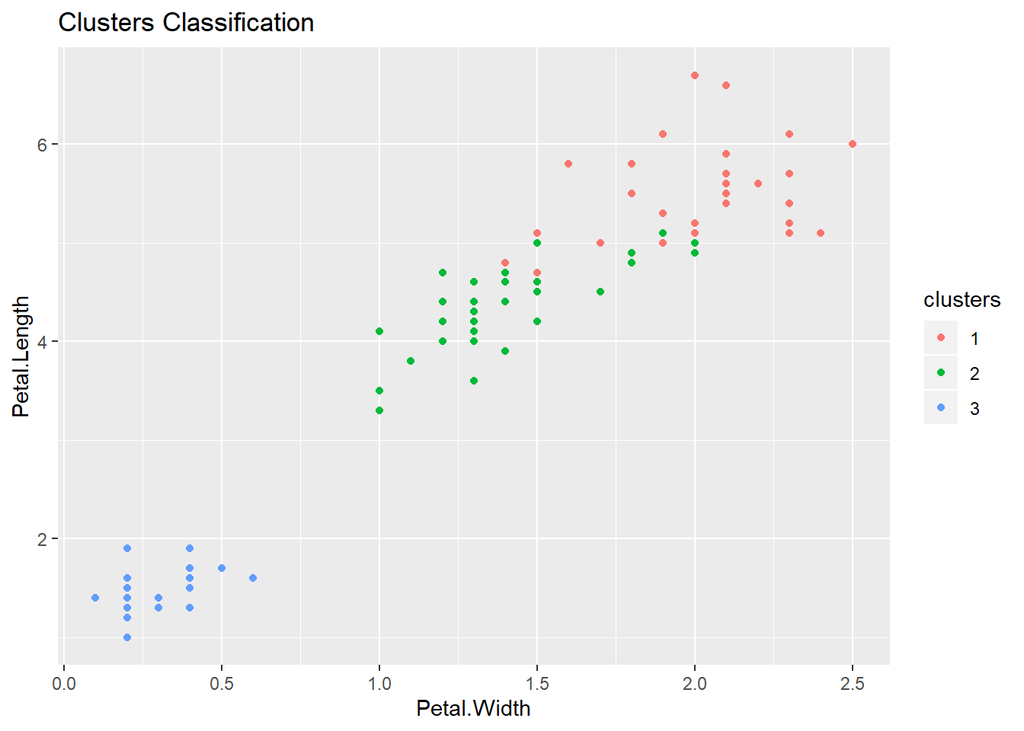

```r
#Cluster with k-means
kMeans1 <-kmeans(subset(training,select=-c(Species)),centers=3)
training$clusters <-as.factor(kMeans1$cluster)
p1 <-qplot(Petal.Width,Petal.Length,color=clusters,data=training)+ggtitle("Clusters Classification")
p1
```

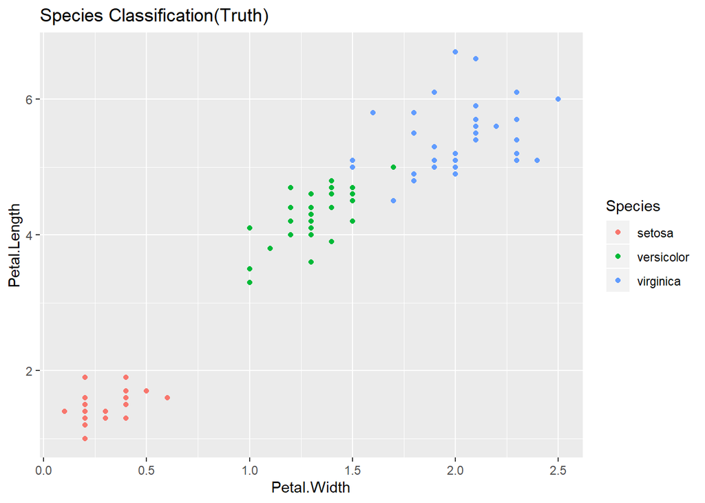

```r
p2 <-qplot(Petal.Width,Petal.Length,color=Species,data=training)+ggtitle("Species Classification(Truth)")
p2
```

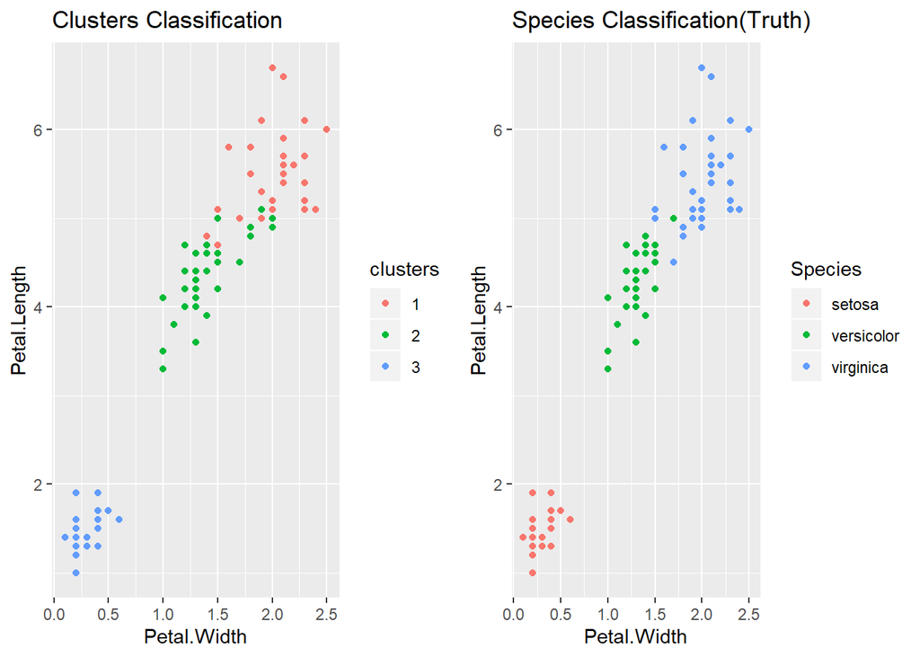

```r
grid.arrange(p1,p2,ncol=2)
```

```r
#Compare to real labels
table(kMeans1$cluster,training$Species)
```

```
##
##     setosa versicolor virginica
##   1      0          4        25
##   2      0         31        10
##   3     35          0         0
```

```r
#Build predictor
modFit <-train(clusters~.,data=subset(training,select=-c(Species)),method="rpart")
modFit
```

```
## CART
##
## 105 samples
##   4 predictor
##   3 classes: '1', '2', '3'
##
## No pre-processing
## Resampling: Bootstrapped (25 reps)
## Summary of sample sizes: 105, 105, 105, 105, 105, 105, ...
## Resampling results across tuning parameters:
##
##   cp        Accuracy   Kappa
##   0.015625  0.8883670  0.8303097
##   0.343750  0.8173375  0.7204783
##   0.546875  0.5124464  0.2602394
##
## Accuracy was used to select the optimal model using the largest value.
## The final value used for the model was cp = 0.015625.
```

```r
table(predict(modFit,training),training$Species)
```

```
##
##     setosa versicolor virginica
##   1      0          1        29
##   2      0         34         6
##   3     35          0         0
```

```r
#aplly on test set
testClusterPred <-predict(modFit,testing)
table(testClusterPred,testing$Species)
```

```
##
## testClusterPred setosa versicolor virginica
##               1      0          1        15
##               2      0         14         0
##               3     15          0         0
```

## Notes and further reading

- The cl_predict function in the clue package provides similar functionality.
- Beware of over interpretation of clusters.
- This is one basic approach to recommendation engines.
- Elements of Statistical Learning.
- Introduction to Statistical Learning.

## Spurious Correlation

- This is a mathematical relationship in which two or more events or variables are not causally related to each other, yet it may be wrongly inferred that they are, due to either coincidence or the presence of a certain third, unseen factor(referred to as confounding factor or common response variable or lurking variable).

## Summary of packages

### Regularized Regression

```r
library(MASS)
library(ggplot2)
library(dplyr)
library(lars)
library(elasticnet)
library(caret)
data(Insurance)
names(Insurance)
```

```
## [1] "District" "Group"    "Age"      "Holders"  "Claims"
```

```r
glimpse(Insurance)
```

```
## Observations: 64
## Variables: 5
## $ District <fct> 1, 1, 1, 1, 1, 1, 1, 1, 1, 1, 1, 1, 1, 1, 1, 1, 2, 2,...
## $ Group    <ord> <1l, <1l, <1l, <1l, 1-1.5l, 1-1.5l, 1-1.5l, 1-1.5l, 1...
## $ Age      <ord> <25, 25-29, 30-35, >35, <25, 25-29, 30-35, >35, <25, ...
## $ Holders  <int> 197, 264, 246, 1680, 284, 536, 696, 3582, 133, 286, 3...
## $ Claims   <int> 38, 35, 20, 156, 63, 84, 89, 400, 19, 52, 74, 233, 4,...
```

```r
tab1 <-table(Insurance$District)
tab1
```

```
##
##  1  2  3  4
## 16 16 16 16
```

```r
tab2 <-table(Insurance$Age)
tab2
```

```
##
##   <25 25-29 30-35   >35
##    16    16    16    16
```

```r
tab3 <-table(Insurance$Group)
tab3
```

```
##
##    <1l 1-1.5l 1.5-2l    >2l
##     16     16     16     16
```

```r
cbind(tab1,tab2,tab3)
```

```
##   tab1 tab2 tab3
## 1   16   16   16
## 2   16   16   16
## 3   16   16   16
## 4   16   16   16
```

```r
inTrain <-createDataPartition(y=Insurance$Holders,p=0.7,list=FALSE)
training <-Insurance[inTrain,]
testing <-Insurance[-inTrain,]
modFit <-lm.ridge(Holders~.,data=training,lambda=5)
modFit
```

```
##               District2   District3   District4     Group.L     Group.Q
##   69.912753  -38.924046  -51.840904 -102.753587  -80.514379   13.444371
##     Group.C       Age.L       Age.Q       Age.C      Claims
##   58.864544  132.716647   87.802670   10.151520    7.003104
```

```r
#Note:the predictors are centered and scaled first before the regression is run
#lambda=5 is the tuning parameter
modFit$xm # returns column/predictor mean from the data
```

```
##     District2     District3     District4       Group.L       Group.Q
##  2.708333e-01  2.291667e-01  2.500000e-01 -6.521865e-02  6.250000e-02
##       Group.C         Age.L         Age.Q         Age.C        Claims
## -3.726780e-02 -5.782412e-19  6.250000e-02 -4.658475e-02  5.168750e+01
```

```r
modFit$scale # returns the scaling performed on the predictors for the ridge regression
```

```
##  District2  District3  District4    Group.L    Group.Q    Group.C
##  0.4443902  0.4202967  0.4330127  0.5203331  0.4960784  0.4728754
##      Age.L      Age.Q      Age.C     Claims
##  0.5244044  0.4960784  0.4720486 76.9421201
```

```r
modFit$coef # returns the conditional coefficients Bj from the ridge regression
```

```
##  District2  District3  District4    Group.L    Group.Q    Group.C
## -17.297464 -21.788560 -44.493608 -41.894296   6.669462  27.835593
##      Age.L      Age.Q      Age.C     Claims
##  69.597197  43.557005   4.792011 538.833700
```

```r
modFit$y # returns mean of outcome
```

```
## [1] 392.6875
```

```r
#perform ridge regression with given outcome and predictors using caret package
modFit1 <-train(Holders~.,data=training,method="ridge",lambda=5)
modFit1
```

```
## Ridge Regression
##
## 48 samples
##  4 predictor
##
## No pre-processing
## Resampling: Bootstrapped (25 reps)
## Summary of sample sizes: 48, 48, 48, 48, 48, 48, ...
## Resampling results across tuning parameters:
##
##   lambda  RMSE      Rsquared   MAE
##   0e+00   127.8536  0.9450450   95.55592
##   1e-04   127.8284  0.9450878   95.53416
##   1e-01   155.3562  0.9333154  120.53165
##
## RMSE was used to select the optimal model using the smallest value.
## The final value used for the model was lambda = 1e-04.
```

### Regularized Regression - Adaptive foreward backward greedy algorithm for learning sparse representation (foba)

```r
library(MASS)
library(ggplot2)
library(dplyr)
library(caret)
data(Insurance)
inTrain <-createDataPartition(y=Insurance$Holders,p=0.7,list=FALSE)
training <-Insurance[inTrain,]
testing <-Insurance[-inTrain,]
#perform ridge regression with variable selection
#lambda = 5 is the tuning parameter
#k=4 is the number of variables that should be retained. This means that length (predictors) - k variables will be eliminated.
```

[output not shown]

### Regularized Regression - LASSO regression

- LASSO; least absolute shrinkage and selection operator was introduced by Tibshirani (Journal of the Royal Statistical society 1996).
- Similar to ridge with slightly different penalty terms.
- We have the penalized regression sum of squares (PRSS).
- Lambda is the tuning parameter and it controls the size of coefficients or the amount of regularization.
- Large values of lambda will set some coefficients equal to zero (0).
- Note; lasso effectively performs model selection (choose subset of predictors) while shrinking other coefficients where as ridge only shrinks the coefficients.
- Note; the predictors are centered and scaled first before the regression is run.
- as.matrix(x); the predictors must be in matrix /dataframe format.
- trace = TRUE prints progress of the lasso regression.
- lasso$lambda returns the lambdas used for each step of the lasso regression.
- plot(lasso) prints plots that shows the regression of the coefficients as they are set to zero one by one.
- predict.lars(lasso,test) uses the lasso model to predict on test data.
- cv.lars(as.matrix(x),y,K=10,type=“lasso”,trace=TRUE) computes K-fold cross validaited mean squared prediction errors for lasso regression.
- Note; lasso regression is a special case of the elastic net regression and forcing lambda=0 tells the function to fit a lasso regression.
- lasso = enet(predictors,outcome,lambda=0) perform elastic net regression on given predictors and outcome.

```r
library(MASS)
library(ggplot2)
library(gridExtra)
library(dplyr)
library(lars)
library(elasticnet)
library(caret)
data(Boston)
dim(Boston)
```

```
## [1] 506  14
```

```r
names(Boston)
```

```
##  [1] "crim"    "zn"      "indus"   "chas"    "nox"     "rm"      "age"
##  [8] "dis"     "rad"     "tax"     "ptratio" "black"   "lstat"   "medv"
```

```r
inTrain <-createDataPartition(y=Boston$tax,p=0.8,list=FALSE)#p=0.8 to make testing data small
training <-Boston[inTrain,]
testing <-Boston[-inTrain,]
lasso <-lars(as.matrix(Boston),y=Boston$tax,type="lasso",trace=TRUE)#perform lasso regression by adding predictors one at time (or setting variables to 0)
```

```
## LASSO sequence
## Computing X'X .....
## LARS Step 1 :     Variable 10    added
## LARS Step 2 :     Variable 9     added
## LARS Step 3 :     Variable 5     added
## LARS Step 4 :     Variable 11    added
## LARS Step 5 :     Variable 2     added
## LARS Step 6 :     Variable 6     added
## LARS Step 7 :     Variable 12    added
## LARS Step 8 :     Variable 4     added
## LARS Step 9 :     Variable 1     added
## LARS Step 10 :    Variable 13    added
## LARS Step 11 :    Variable 14    added
## LARS Step 12 :    Variable 3     added
## LARS Step 13 :    Variable 8     added
## LARS Step 14 :    Variable 7     added
## Computing residuals, RSS etc .....
```

```r
lasso$lambda #returns the lambdas used for each step of the lasso regression
```

```
##  [1] 3.787401e+03 1.500666e-10 2.336679e-11 1.454444e-11 5.527807e-12
##  [6] 2.935248e-12 2.833252e-12 2.239772e-12 1.878931e-12 1.148600e-12
## [11] 6.756667e-13 3.025153e-13 2.979365e-13 2.547326e-13
```

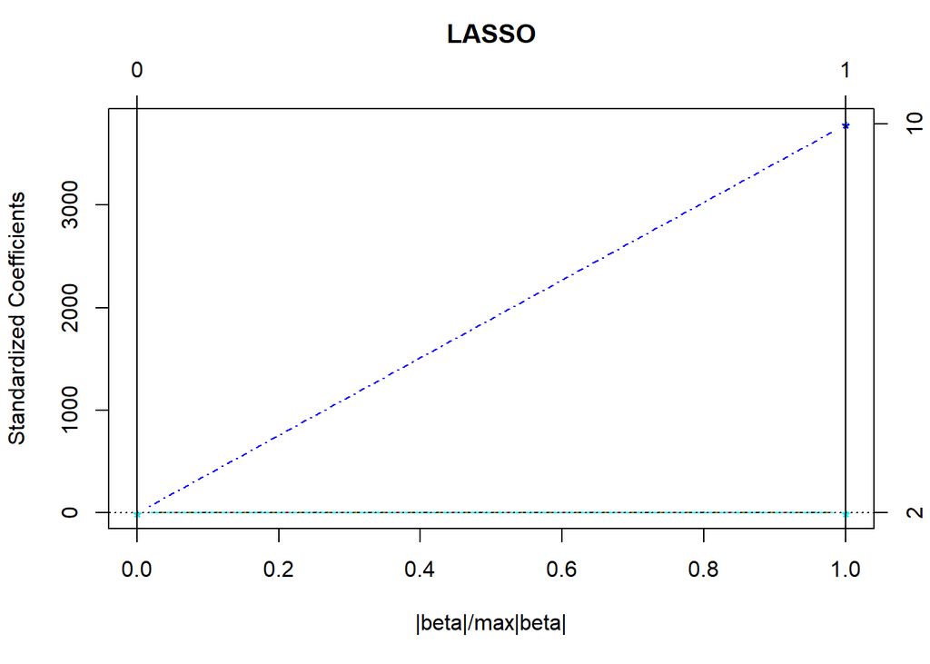

```r
plot(lasso)
```

```r
predict.lars(lasso,testing)
```

```
## $s
##  [1]  1  2  3  4  5  6  7  8  9 10 11 12 13 14 15
##
## $fraction
##  [1] 0.00000000 0.07142857 0.14285714 0.21428571 0.28571429 0.35714286
##  [7] 0.42857143 0.50000000 0.57142857 0.64285714 0.71428571 0.78571429
## [13] 0.85714286 0.92857143 1.00000000
##
## $mode
## [1] "step"
##
## $fit
##         [,1] [,2] [,3] [,4] [,5] [,6] [,7] [,8] [,9] [,10] [,11] [,12]
## 4   408.2372  222  222  222  222  222  222  222  222   222   222   222
## 8   408.2372  311  311  311  311  311  311  311  311   311   311   311
```

[output cut: 199 more lines]

```r
cv.lars(as.matrix(Boston),y=Boston$tax,K=10,type="lasso",trace=TRUE)
```

[output not shown]

[output cut: 144 more lines]

```
## LARS Step 3 :     Variable 14    added
## LARS Step 4 :     Variable 1     added
## LARS Step 5 :     Variable 11    added
## LARS Step 6 :     Variable 12    added
## LARS Step 7 :     Variable 3     added
## LARS Step 8 :     Variable 4     added
## LARS Step 9 :     Variable 7     added
## LARS Step 10 :    Variable 5     added
## LARS Step 11 :    Variable 2     added
## LARS Step 12 :    Variable 8     added
## LARS Step 13 :    Variable 13    added
## LARS Step 14 :    Variable 6     added
## Computing residuals, RSS etc .....
##
##  CV Fold 10
```

[figure not shown]

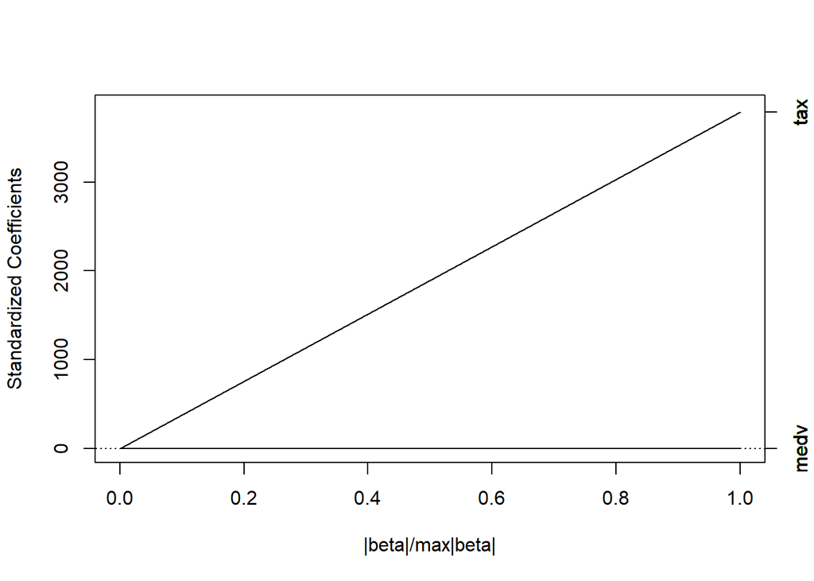

```r
lasso1 <-enet(as.matrix(Boston),y=Boston$tax,lambda=0)#perform elastic net regression on given predictors and outcome
plot(lasso1)#print plot that shows the progression of the coefficients as they are set to zero one by one
```

```r
predict.enet(lasso1,testing)
```

```
## $s
##  [1]  1  2  3  4  5  6  7  8  9 10 11 12 13 14 15
##
## $fraction
##  [1] 0.00000000 0.07142857 0.14285714 0.21428571 0.28571429 0.35714286
##  [7] 0.42857143 0.50000000 0.57142857 0.64285714 0.71428571 0.78571429
## [13] 0.85714286 0.92857143 1.00000000
##
## $mode
## [1] "step"
##
## $fit
##            0   1   2   3   4   5   6   7   8   9  10  11  12  13  14
## 4   408.2372 222 222 222 222 222 222 222 222 222 222 222 222 222 222
## 8   408.2372 311 311 311 311 311 311 311 311 311 311 311 311 311 311
```

[output cut: 98 more lines]

```r
#caret package
modFit <-train(tax~.,data=training,method="lasso")
modFit$finalModel
```

```
##
## Call:
## elasticnet::enet(x = as.matrix(x), y = y, lambda = 0)
## Cp statistics of the Lasso fit
## Cp: 3290.707  980.761   92.486   40.528   36.173   15.212    7.744    8.032    7.028    8.585   10.467   10.601   12.360   14.000
## DF:  1  2  3  4  5  6  7  8  9 10 11 12 13 14
## Sequence of  moves:
##      rad indus medv zn chas nox ptratio age crim lstat rm dis black
## Var    9     3   13  2    4   5      10   7    1    12  6   8    11 14
## Step   1     2    3  4    5   6       7   8    9    10 11  12    13 14
```

```r
pred <-predict(modFit,testing)
pred
```

```
##        4        8       14       25       29       31       34       38
## 230.9213 316.6336 308.7797 316.0805 312.9206 319.0907 318.9744 301.7977
##       51       61       62       64       67       69       83       88
## 297.2870 357.9848 362.8859 349.0530 319.9724 297.6958 289.7799 260.6787
##       90       91       95      108      112      113      123      124
## 232.5469 239.8865 372.8153 326.0659 345.1342 350.3571 406.9270 410.4909
##      132      133      136      139      141      148      157      161
## 413.1348 409.2290 414.6638 420.1610 418.7635 417.3519 419.8874 373.1168
##      164      168      169      171      176      182      193      195
## 345.6725 396.9854 398.0804 405.4979 275.4773 230.5329 289.9900 248.7369
##      198      201      204      214      215      219      228      234
## 262.9913 287.1791 290.4828 310.8267 313.2831 338.1794 333.3368 312.9715
##      238      247      254      258      261      263      264      271
## 333.0762 337.2845 313.5622 268.8811 287.7182 270.6196 291.7360 293.0098
##      276      277      290      296      302      309      316      318
## 303.0104 280.3060 336.0155 329.5716 347.3571 317.5789 324.7822 319.7834
##      322      329      333      336      338      341      344      345
## 310.5305 265.6613 267.8337 297.3293 301.9495 301.7119 320.2092 309.7923
##      350      376      386      401      403      406      408      411
## 231.7600 667.8029 677.4459 678.7872 672.5675 676.7245 653.1568 663.5535
##      417      420      423      424      432      437      438      444
## 676.3714 675.8600 659.0006 667.2507 665.8808 676.5495 677.4803 670.3790
##      445      448      456      460      463      470      478      482
## 675.1699 673.6857 670.4762 663.5046 664.0223 656.4164 669.1846 652.5064
##      483      486      487      490
## 651.0995 655.7598 659.7091 467.6286
```

### Regularized Regression - relaxo regression

- Performs relaxed lasso regression on given predictors and outcome.
- lambda = 5 say, is the tuning parameter.
- phi = 0.3 say, is the relaxation parameter.
- phi = 1 corresponds to the regular lasso solutions.
- phi = 0 computes the OLS estimates on the set of variables selected by the lasso.

```r
library(MASS)
library(ggplot2)
library(gridExtra)
library(dplyr)
library(lars)
library(elasticnet)
library(relaxo)
library(caret)
data(Boston)
dim(Boston)
```

```
## [1] 506  14
```

```r
names(Boston)
```

```
##  [1] "crim"    "zn"      "indus"   "chas"    "nox"     "rm"      "age"
##  [8] "dis"     "rad"     "tax"     "ptratio" "black"   "lstat"   "medv"
```

```r
inTrain <-createDataPartition(y=Boston$tax,p=0.7,list=FALSE)#p=0.8 to make testing data small
training <-Boston[inTrain,]
testing <-Boston[-inTrain,]
#modFit <-train(tax~.,data=training,method="relaxo",lambda=5,phi=0.3)
#modFit$finalModel
#pred1 <-predict(modFit,testing)
#pred1
#perform lasso regression
lasso.fit <-lars(as.matrix(Boston),y=Boston$tax,type="lasso",trace=TRUE)
```

```
## LASSO sequence
## Computing X'X .....
## LARS Step 1 :     Variable 10    added
## LARS Step 2 :     Variable 9     added
## LARS Step 3 :     Variable 5     added
## LARS Step 4 :     Variable 11    added
## LARS Step 5 :     Variable 2     added
## LARS Step 6 :     Variable 6     added
## LARS Step 7 :     Variable 12    added
## LARS Step 8 :     Variable 4     added
## LARS Step 9 :     Variable 1     added
## LARS Step 10 :    Variable 13    added
## LARS Step 11 :    Variable 14    added
## LARS Step 12 :    Variable 3     added
## LARS Step 13 :    Variable 8     added
## LARS Step 14 :    Variable 7     added
## Computing residuals, RSS etc .....
```

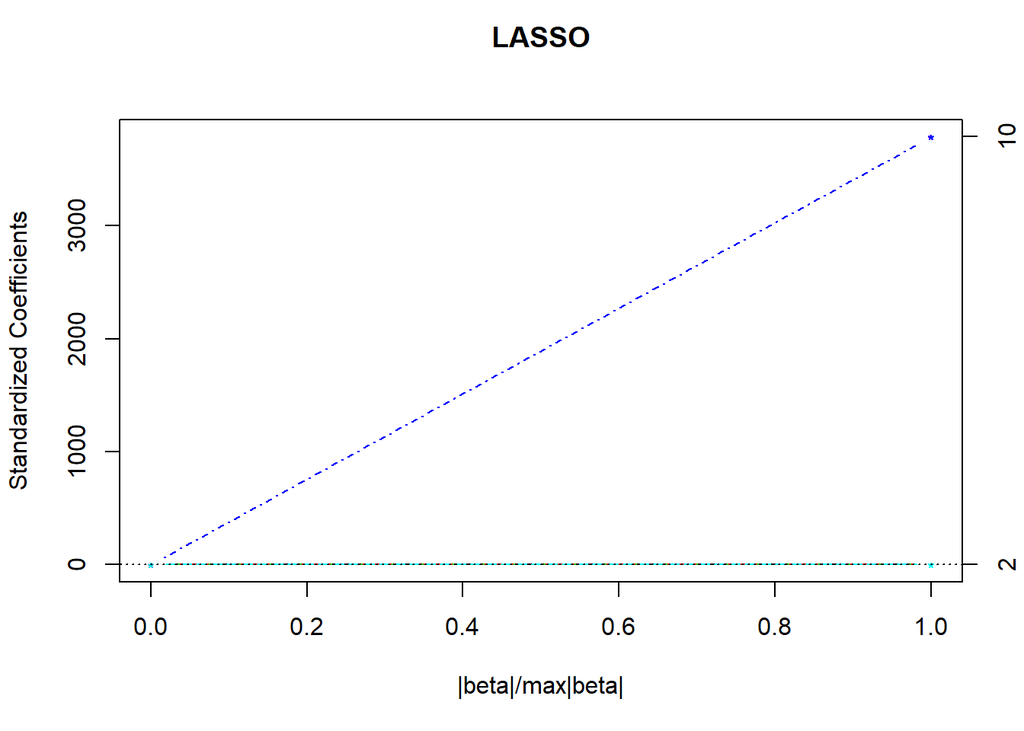

```r
#plot lasso regression model
plot(lasso.fit,breaks=FALSE,cex=0.75)
```